# Plan de rédaction des résultats scientifiques

Pour que vos résultats ne restent pas… sans suite

Cédric Albert

8 octobre 2026

## Toujours trop de résultats !

« Des résultats ? J’en ai plein.  
Je connais des milliers de choses qui **ne fonctionnent pas**. »

— Thomas A. Edison

## Aujourd’hui

Partie 1 — Écrire ses résultats

- ce qu’on **met** (et ce qu’on ne met **pas**)
- comment **organiser** ses données
- texte, tableau ou figure ?
- **statistiques** et décimales
- exercice : trouver les erreurs

Partie 2 — Présenter ses résultats à l’oral

- pourquoi un tableau d’article échoue à l’écran
- trois réflexes pour une présentation vivante
- un titre qui **affirme**
- vrai ou faux

# Partie 1 — Écrire ses résultats

Quoi dire, dans quel ordre, et quoi laisser de côté

## La section Résultats : le cœur du travail

Introduction

*Pourquoi* cette étude ?

Méthodes

*Comment* l’avons-nous faite ?

Résultats

*Qu’avons-nous trouvé ?*  
La **nouveauté brute** que vous apportez.

Discussion

Qu’est-ce que *cela signifie* ?

Sans résultats solides et clairs, tout le reste de la recherche s’effondre. 💩

## Les deux ingrédients

1 · La vue d’ensemble

Le portrait général de vos expériences, **sans répéter** les détails méthodologiques déjà donnés.

2 · Les données elles-mêmes

Présentées **au passé**, organisées et **sélectionnées**.

Exemple de vue d’ensemble

> « Nous avons suivi le diamètre au collet de 240 semis d’épinette noire soumis à trois intensités de coupe partielle (80 semis par traitement) pendant cinq saisons de croissance. »

Pas besoin de réexpliquer ici comment chaque tige a été mesurée.

## Ce qu’on ne met **pas** dans les résultats

La méthode, encore

> « Le diamètre a été mesuré au pied à coulisse numérique, à 1 cm du sol… »

Sa place

Matériel et méthodes

L’interprétation

> « …ce qui suggère que la lumière limite la croissance. »

Sa place

Discussion

La littérature

> « …ce qui concorde avec Smith (2018). »

Sa place

Discussion

🔎 Le test de chaque phrase : **est-ce une observation ?** Sinon, elle appartient à une autre section.

## Comment organiser ? Trois façons

1 · Chronologique

Pour un suivi dans le temps.

*Croissance d’une plantation sur 10 ans.*

2 · Par thème

Sous-titres qui font écho aux Méthodes.

*Survie · Croissance en hauteur · Composition*

3 · Par importance

On commence par le résultat qui change vraiment la donne.

🌲 Une étude sur le reboisement après feu pourrait suivre l’ordre **régénération naturelle → régénération assistée → mortalité par site**, plutôt qu’un fouillis chronologique de visites de terrain.

## Exemple : organisation chronologique

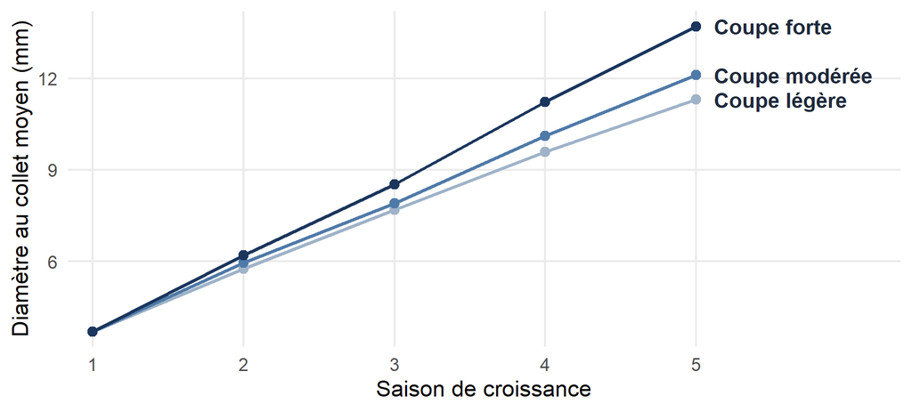

## Représentatif, pas répétitif

« Le fou amasse les faits ;  
le sage les **choisit**. »

— John Wesley Powell, géologue (1888)

## Représentatif, pas répétitif

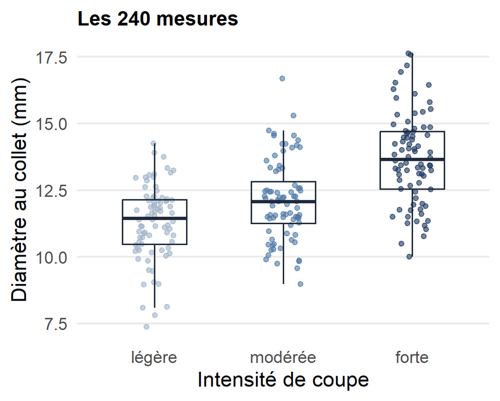

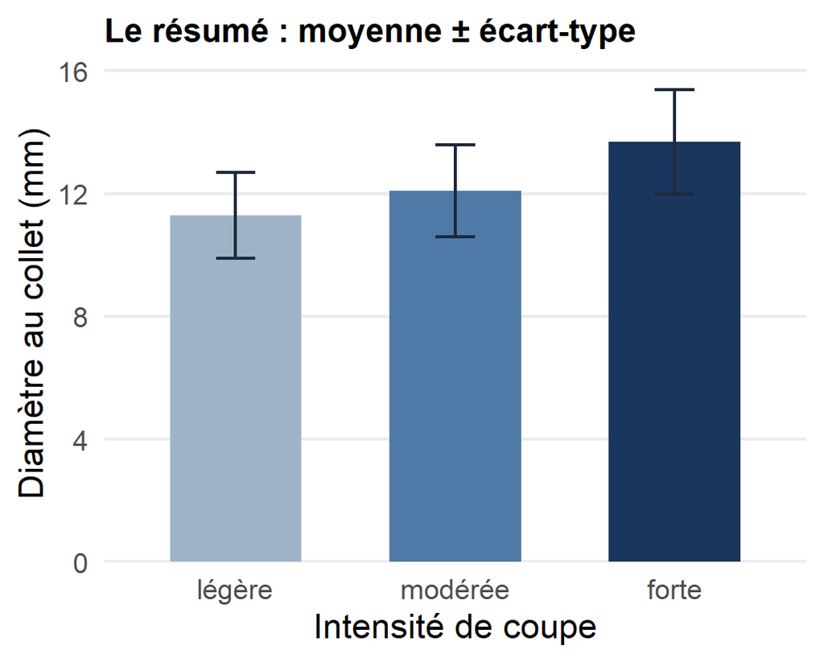

## Exemple : trop ou juste assez

Trop

> « Le semis 1 mesurait 12,3 mm ; le semis 2, 12,1 mm ; le semis 3, 11,9 mm… [237 semis plus tard] »

Juste assez

> « Le diamètre au collet moyen des semis a atteint 12,4 ± 1,8 mm (moyenne ± ET) après cinq saisons (n = 240 ; tableau 1). »

🎯 **Un résultat négatif compte aussi** : « Aucune différence de survie n’a été détectée entre les trois intensités de coupe (survie ≥ 90 % dans tous les traitements ; χ² = 0,31 ; p = 0,86). » Savoir ce qui **n’a pas** d’effet est une information utile.

## Où mettre quoi ?

Texte

**Une ou deux valeurs** isolées.

Tableau

**Valeurs exactes** nombreuses ou répétitives.

Figure

**Tendance**, comparaison, forme d’une relation.

Le texte **commente** le tableau, il ne le **répète** pas.

> « Le tableau 1 montre clairement que la hauteur moyenne des plants variait selon le traitement de scarifiage, comme on peut le voir dans le tableau 1. »

> « La hauteur moyenne des plants variait selon le traitement de scarifiage (tableau 1). »

## Le même résultat, en tableau

**Tableau 1.** Diamètre au collet des semis d’épinette noire après cinq saisons, selon l’intensité de coupe.

| Traitement | n | Diamètre au collet moyen (mm) | Écart-type (mm) |
| --- | --- | --- | --- |
| Coupe légère | 80 | 11,3 | 1,4 |
| Coupe modérée | 80 | 12,1 | 1,5 |
| Coupe forte | 80 | 13,7 | 1,7 |

Dans le texte, on ne répète pas ces six chiffres : « Le diamètre au collet moyen augmentait avec l’intensité de la coupe (tableau 1). »

## Le même résultat, en figure

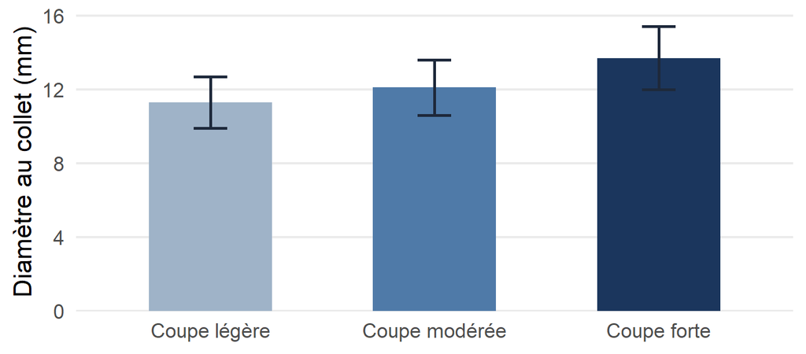

**Figure 1.** Diamètre au collet moyen (± écart-type) des semis d’épinette noire après cinq saisons, selon l’intensité de coupe (n = 80 semis par traitement).

Tableau : titre **au-dessus** · Figure : légende **en dessous** · les deux **autonomes**.

## Les statistiques, c’est compliqué !

« 33,3 % des souris ont guéri.  
33,3 % sont restées inchangées.  
La troisième souris… s’est **sauvée**. »

## Rapporter un résultat statistique complet

Incomplet

> « La différence entre les traitements était significative (p < 0,05). »

Complet

> « Le diamètre au collet était plus grand sous coupe forte que sous coupe légère (13,7 contre 11,3 mm ; différence : 2,4 mm, IC 95 % : 1,9 à 2,9 ; t de Welch, t(152) = 9,7, p < 0,001). »

Direction + Ampleur + Incertitude (IC ou ET) et n + Test et p exact

**« ± quoi ? »** Précisez toujours s’il s’agit d’un écart-type (ET), d’une erreur-type (ES) ou d’un intervalle de confiance (IC).

## Le piège des décimales

Si 17 arbres sur 59 ont survécu à une sécheresse…

> « 28,8136 % des arbres ont survécu. »

> « 17 des 59 arbres (29 %) ont survécu. »

Ce n’est pas parce que votre calculatrice affiche huit chiffres qu’il faut tous les écrire.  
📏 Les décimales suivent la **précision de la mesure** · 🔢 avec un petit n, donnez **le compte** avec le pourcentage.

## Clarté avant élégance

« Si vous voulez décrire la vérité,  
laissez l’élégance au tailleur. »

— Attribuée à Albert Einstein

## Attention aux pronoms flottants

> « La jambe gauche était engourdie par moments… Le deuxième jour, le genou allait mieux, et le troisième jour, **il** avait complètement disparu. »

De quoi parle ce « il » ? De l’engourdissement ? Du genou ? Le lecteur devine, et devine mal.

🌲 **Version forestière**

> « Les semis ont été plantés sous les arbres résiduels. Après deux saisons, **ils** montraient des signes de stress hydrique. »

> « …Après deux saisons, **les semis** montraient des signes de stress hydrique. »

## Et le matériel supplémentaire ?

- Données brutes, tableaux étendus, figures additionnelles → souvent déposés **en ligne**, hors du corps du texte (annexes, dépôt de données).
- Les normes varient énormément d’une revue, d’un programme ou d’un directeur à l’autre.
- **Vérifiez toujours** les exigences avant de tout entasser en annexe.

Le matériel supplémentaire **complète** l’article ; il ne doit jamais contenir un résultat nécessaire pour comprendre la conclusion.

## Exercice : trouvez les cinq erreurs

> « Comme mentionné dans la méthodologie, le diamètre au collet a été mesuré au pied à coulisse numérique sur chacun des 240 semis. Le tableau 1 montre que le diamètre moyen était de 11,3125 mm sous coupe légère, de 12,0875 mm sous coupe modérée et de 13,7042 mm sous coupe forte, comme on peut le voir dans le tableau 1. Cette différence était significative. Elle s’explique probablement par une plus grande disponibilité de la lumière, ce qui concorde avec Smith (2018). »

✏️ En équipe de deux : soulignez les erreurs, puis réécrivez le paragraphe en **deux phrases**.

## Corrigé

1 Comme mentionné dans la méthodologie, … mesuré au pied à coulisse… → méthode répétée

2 Le tableau 1 montre que… comme on peut le voir dans le tableau 1 → le texte répète le tableau

3 11,3125 · 12,0875 · 13,7042 mm → fausse précision

4 Cette différence était significative. → laquelle ? de combien ? quel test ?

5 Elle s’explique probablement… Smith (2018) → interprétation et littérature : Discussion

Version corrigée

> « Le diamètre au collet moyen augmentait avec l’intensité de la coupe (tableau 1). Après cinq saisons, il atteignait 13,7 mm sous coupe forte, contre 11,3 mm sous coupe légère (différence : 2,4 mm ; IC 95 % : 1,9 à 2,9 ; p < 0,001). »

# Partie 2 — Présenter ses résultats à l’oral

Les mêmes résultats, sans vider la salle

## Un jeu de données ≠ une bonne diapositive

Ce qui fonctionne dans un tableau d’article **ne fonctionne presque jamais** projeté tel quel sur un écran.

🌲 Un tableau de 12 lignes × 8 colonnes de mesures dendrométriques : personne ne le lit, tout le monde décroche.

## La preuve, en direct

| Semis | Traitement | Bloc | Diam_collet_mm | Hauteur_cm | Biomasse_g | Etat_sanitaire | Releve |
| --- | --- | --- | --- | --- | --- | --- | --- |
| 1 | Coupe modérée | B | 13.24 | 121.8 | 89.7 | Moyen | Équipe B |
| 2 | Coupe forte | D | 10.79 | 90.3 | 103.3 | Moyen | Équipe B |
| 3 | Coupe forte | C | 11.85 | 104.5 | 74.5 | Bon | Équipe B |
| 4 | Coupe forte | D | 12.39 | 92.6 | 80.7 | Faible | Équipe A |
| 5 | Coupe modérée | D | 14.18 | 124.4 | 65.3 | Bon | Équipe B |
| 6 | Coupe forte | B | 13.91 | 112.2 | 79.1 | Faible | Équipe A |
| 7 | Coupe modérée | C | 13.67 | 108.4 | 79.0 | Faible | Équipe B |
| 8 | Coupe modérée | C | 14.75 | 101.6 | 105.3 | Moyen | Équipe A |
| 9 | Coupe forte | B | 9.90 | 98.8 | 93.9 | Bon | Équipe A |
| 10 | Coupe modérée | D | 14.69 | 130.0 | 86.5 | Bon | Équipe A |
| 11 | Coupe forte | B | 12.73 | 87.9 | 99.0 | Bon | Équipe B |
| 12 | Coupe forte | C | 13.75 | 107.2 | 81.1 | Faible | Équipe B |

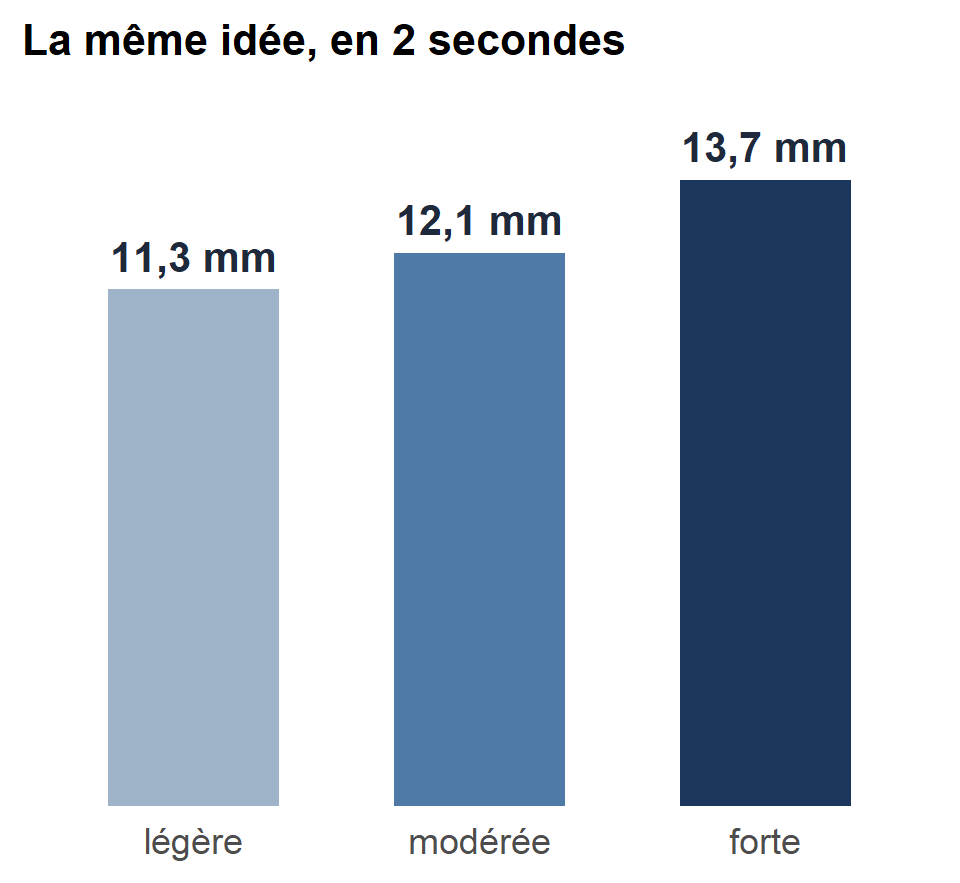

## Trois réflexes pour une présentation vivante

1 · Une idée par diapositive

Pas un paragraphe entier à l’écran.

2 · La figure remplace le tableau

Une tendance se *voit*, elle ne se *lit* pas.

3 · Racontez avant de montrer

« Et là, surprise : la parcelle brûlée a mieux régénéré que la parcelle coupée »… *puis* le graphique.

## Un titre qui affirme

Titre-étiquette

Résultats : diamètre au collet

Titre-message

La coupe forte a augmenté le diamètre des semis de 21 %

Le titre dit **ce qu’il faut retenir** ; la figure en apporte **la preuve**. Si l’auditoire ne lit que les titres, il comprend quand même votre histoire.

## Vrai ou faux ?

- On peut lire son tableau de résultats à voix haute pendant la présentation. Faux
- Une figure doit pouvoir se comprendre sans que vous parliez. Vrai
- Il faut présenter TOUTES ses données pour être crédible. Faux
- La figure de l’article peut être projetée telle quelle. Faux

## Petit résumé

À l’écrit

- vue d’ensemble d’abord, données ensuite
- au passé, organisation logique, sans répéter la méthode
- représentatif > exhaustif
- texte pour 1-2 valeurs ; tableau ou figure pour le reste
- le texte commente le tableau, il ne le répète pas
- statistiques complètes, sans fausse précision
- antécédents clairs pour « il », « cela », « celui-ci »

À l’oral

- une idée par diapositive
- la figure plutôt que le tableau brut
- des figures plus simples que dans l’article
- un titre qui affirme le message
- raconter le résultat avant de le montrer

## Et ensuite ? Des résultats à la discussion

Résultats : *qu’avons-nous observé ?* → Discussion : *que signifient ces observations ?*

> « Le diamètre au collet moyen augmentait avec l’intensité de la coupe (tableau 1). »

La discussion devra demander : **Pourquoi ? Par rapport à quoi ? Est-ce cohérent avec la littérature ? Qu’est-ce que cela change ?**

📅 Au prochain cours : **la discussion scientifique**.

# Merci !

**Questions ?**

Basé sur : Day, R. A. et Gastel, B. *How to Write and Publish a Scientific Paper*, 9<sup>e</sup> éd., chapitre 12.

Exemples pédagogiques et données simulées préparés pour l’enseignement de la rédaction scientifique.